## Assignment 10

### Preliminaries

- Directories
  - COURSE/homework/
  - COURSE/homework/hw10/
  - COURSE/data/
  - COURSE/scripts/
- Files
  - COURSE/homework/hw10/hw10.Rmd
  - COURSE/data/boston-marathon-data.csv
  - COURSE/data/madison-weather-official-1869-2023.csv
  - COURSE/scripts/viridis.R
  - COURSE/scripts/ggprob.R

### Data

- Some problems use the official Madison weather data, `madison-weather-official-1869-2023.csv`.
- Additional problems use the Boston Marathon data in the file `boston-marathon-data.csv`. This file is a transformed version of the raw data we used in class and has data for all runners who completed the race in 2010 and 2011. The variable `Time` is the sum of the times from the different portions of the race, each of which begins with “K”.

### Aims

- Practice inference on means

## Problems

#### 1

Read in the official Madison weather data. Treat the high temperatures on the dates from April 14 from the twenty year period (2001–2020) as a random sample from a population of potential maximum temperatures in Madison under recent climate conditions at this time of the year. Let $\mu$ and $\sigma$ represent the unknown mean and standard deviations of this population of high temperatures.

-1a. Calculate and display the summary statistics $n$, $\bar{x}$, and $s$, the sample standard deviation.

```r
data = read_csv("../../data/madison-weather-official-1869-2023.csv")
data
```

```
## # A tibble: 56,612 × 8
##    name   date        prcp  snow snow_depth  tmin  tmax  tavg
##    <chr>  <date>     <dbl> <dbl>      <dbl> <dbl> <dbl> <dbl>
##  1 Bureau 1869-01-01  0       NA         NA    21    25  23
##  2 Bureau 1869-01-02  0.5     NA         NA    22    30  26
##  3 Bureau 1869-01-03  0       NA         NA    30    37  33.5
##  4 Bureau 1869-01-04  0.03    NA         NA    22    35  28.5
##  5 Bureau 1869-01-05  0       NA         NA    18    25  21.5
##  6 Bureau 1869-01-06  0       NA         NA    26    42  34
##  7 Bureau 1869-01-07  0       NA         NA    29    40  34.5
##  8 Bureau 1869-01-08  0       NA         NA    23    29  26
##  9 Bureau 1869-01-09  0       NA         NA     9    23  16
## 10 Bureau 1869-01-10  1.12    NA         NA     0    13   6.5
## # ℹ 56,602 more rows
```

```r
filtered_data = data %>%
  filter(year(date) >= 2001 &
           year(date) <= 2020 &
           month(date) == 4 &
           day(date) == 14) %>%
  select(date, tmax)

summary_stats = filtered_data %>%
  summarize(n = n(),
            mean = mean(tmax),
            sd = sd(tmax))
summary_stats
```

```
## # A tibble: 1 × 3
##       n  mean    sd
##   <int> <dbl> <dbl>
## 1    20  60.6  15.3
```

-1b. Create a graph to display the distribution of this data. Choose which type of graph is effective for this purpose.

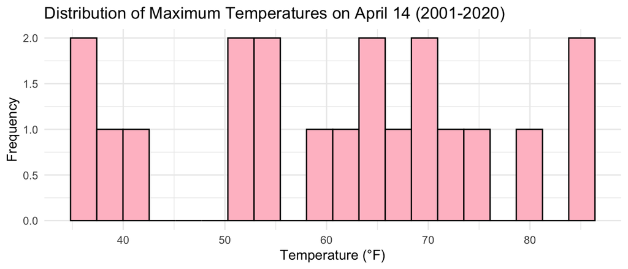

```r
ggplot(filtered_data, aes(x = tmax)) +
  geom_histogram(bins = 20,
                 fill = "pink",
                 color = "black") +
  labs(title = "Distribution of Maximum Temperatures on April 14 (2001-2020)",
       x = "Temperature (°F)",
       y = "Frequency")
```

-1c. Describe the distribution of daily maximum temperatures as shown by the graph. Is the distribution strongly skewed? Are there unusual measurements?

#### 2

Compare the standard normal distribution with the t distribution with 19 degrees of freedom.

-2a. Calculate the 0.975 quantiles from each of these two distribution.

```r
quantile_normal <- qnorm(0.975)

quantile_t <- qt(0.975, df = 19)

quantile_normal
```

```
## [1] 1.959964
```

```r
quantile_t
```

```
## [1] 2.093024
```

-2b. On the same graph, display the density functions of these two distributions, using blue for normal and red for t. - Add colored (using the same color scheme) dashed vertical lines at the corresponding 0.975 quantiles. - Shade the area in tail areas below the 0.025 and above the 0.975 quantiles of each distribution, setting `alpha = 0.5` for partial transparency.

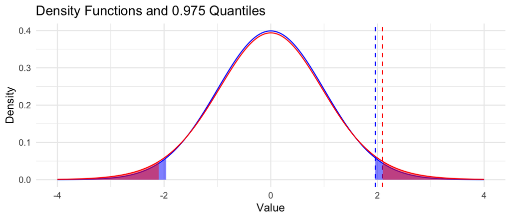

```r
x_values <- seq(-4, 4, by = 0.01)

plot_data <- data.frame(
  x = x_values,
  dnorm = dnorm(x_values),
  dt = dt(x_values, df = 19)
)

ggplot(plot_data, aes(x = x)) +
  geom_line(aes(y = dnorm), color = "blue") +
  geom_line(aes(y = dt), color = "red") +
  geom_vline(xintercept = quantile_normal, color = "blue", linetype = "dashed") +
  geom_vline(xintercept = quantile_t, color = "red", linetype = "dashed") +
  geom_ribbon(aes(ymax = dnorm), ymin = 0, xmax = quantile_normal, data = plot_data %>% filter(x >= quantile_normal), fill = "blue", alpha = 0.5) +
  geom_ribbon(aes(ymax = dt), ymin = 0, xmax = quantile_t, data = plot_data %>% filter(x >= quantile_t), fill = "red", alpha = 0.5) +
  geom_ribbon(aes(ymax = dnorm), ymin = 0, xmin = quantile_normal, data = plot_data %>% filter(x <= -quantile_normal), fill = "blue", alpha = 0.5) +
  geom_ribbon(aes(ymax = dt), ymin = 0, xmin = quantile_t, data = plot_data %>% filter(x <= -quantile_t), fill = "red", alpha = 0.5) +
  labs(title = "Density Functions and 0.975 Quantiles",
       x = "Value",
       y = "Density")
```

#### 3

Using the data from Problem 1:

-3a. Construct a 95% confidence interval for $\mu$ using the theory of the t distribution by direct calculation using the summary statistics from the first part of the problem.

```r
n <- summary_stats$n
mean <- summary_stats$mean
sd <- summary_stats$sd

se <- sd / sqrt(n)

margin_error <- qt(0.975, df = n - 1) * se

ci_lower <- mean - margin_error
ci_upper <- mean + margin_error

# Display the confidence interval
ci_lower
```

```
## [1] 53.47905
```

```r
ci_upper
```

```
## [1] 67.82095
```

-3b. Then use the `t.test()` function to verify your calculation.

```r
t_test_result <- t.test(filtered_data$tmax, conf.level = 0.95)
t_test_result
```

```
##
##  One Sample t-test
##
## data:  filtered_data$tmax
## t = 17.702, df = 19, p-value = 2.892e-13
## alternative hypothesis: true mean is not equal to 0
## 95 percent confidence interval:
##  53.47905 67.82095
## sample estimates:
## mean of x
##     60.65
```

-3c. Interpret this interval in context.

#### 4

The historical average daily high temperature in Madison in April prior to 2000 is 55.6 degrees Farhenheit. Let $\mu$ be the expected daily high temperature on April 14 between 2001 and 2020.

-4a. Use a hypothesis test to test if $\mu$ equals 55.6 degrees versus the alternative that it is different. Include all steps as in the lecture notes.

```r
n <- summary_stats$n
mean <- summary_stats$mean
sd <- summary_stats$sd
historical_mean <- 55.6

t_statistic <- (mean - 55.6) / (sd / sqrt(n))

df <- n - 1

p_value <- 2 * pt(-abs(t_statistic), df)

t_statistic
```

```
## [1] 1.473971
```

```r
p_value
```

```
## [1] 0.1568656
```

-4b. Conclude your hypothesis test with an interpretation in context which states your conclusion in plain language without technical jargon and summarizes the statistical evidence to support your conclusion in a statement surrounded by parentheses.

> Given the p-value of 0.1569 from the hypothesis test, we do not have sufficient evidence to reject the null hypothesis; therefore, we conclude that there is no significant difference between the average daily high temperature on April 14 between 2001 and 2020 and the historical average of 55.6°F prior to 2000.

#### 5

This problem asks you to compare the latest date in each winter when there was at least one inch of snow for two different time periods using the official Madison weather data

-5a. Create a data set with the latest date from January to June in each year where there was at least one inch of snow for the years 1901–1920 and 2001–2020. - Use the **lubridate** function `yday()` to create a new variable `yday` by converting this date into the number of days after December 31. - Add a variable named `period` which has the value `"early 1900s"` for years 1901–1920 and `"early 2000s"` for the years 2001–2020.

```r
latest_snow_dates <- data %>%
  filter(year(date) %in% c(1901:1920, 2001:2020),
         month(date) >= 1,
         month(date) <= 6,
         snow >= 1) %>%
  group_by(year = year(date)) %>%
  summarize(date = max(date)) %>%
  ungroup() %>%
  mutate(yday = yday(date),
         period = case_when(
           year >= 1901 & year <= 1920 ~ "early 1900s",
           year >= 2001 & year <= 2020 ~ "early 2000s"
         ))

latest_snow_dates
```

```
## # A tibble: 39 × 4
##     year date        yday period
##    <dbl> <date>     <dbl> <chr>
##  1  1901 1901-03-10    69 early 1900s
##  2  1903 1903-04-21   111 early 1900s
##  3  1904 1904-03-14    74 early 1900s
##  4  1905 1905-04-21   111 early 1900s
##  5  1906 1906-04-05    95 early 1900s
##  6  1907 1907-04-07    97 early 1900s
##  7  1908 1908-02-19    50 early 1900s
##  8  1909 1909-03-09    68 early 1900s
##  9  1910 1910-04-23   113 early 1900s
## 10  1911 1911-04-06    96 early 1900s
## # ℹ 29 more rows
```

-5b. Calculate the sample size, the sample mean, and the sample standard deviation for each period.

```r
stats_by_period <- latest_snow_dates %>%
  group_by(period) %>%
  summarize(
    sample_size = n(),
    mean_yday = mean(yday),
    sd_yday = sd(yday)
  )

stats_by_period
```

```
## # A tibble: 2 × 4
##   period      sample_size mean_yday sd_yday
##   <chr>             <int>     <dbl>   <dbl>
## 1 early 1900s          19      83.4    19.1
## 2 early 2000s          20      90.8    15.9
```

-5c. Create a graph to compare these two distributions.

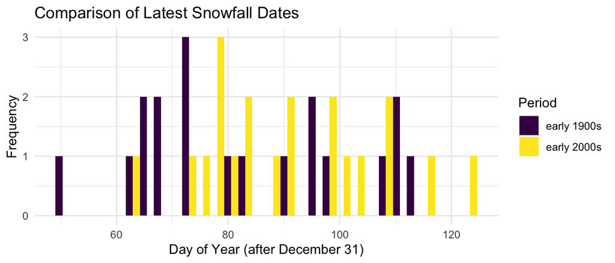

```r
ggplot(latest_snow_dates, aes(x = yday, fill = period)) +
  geom_histogram(position = "dodge") +
  labs(title = "Comparison of Latest Snowfall Dates",
       x = "Day of Year (after December 31)",
       y = "Frequency",
       fill = "Period") +
  theme_minimal()
```

#### 6

Using the data from the previous problem:

-6a. Use `t.test()` to construct a confidence interval for the difference in the mean last day of at least one inch of snow between these two time periods.

```r
t.test(yday ~ period, data = latest_snow_dates, var.equal = TRUE, conf.level = 0.95)
```

```
##
##  Two Sample t-test
##
## data:  yday by period
## t = -1.3316, df = 37, p-value = 0.1911
## alternative hypothesis: true difference in means between group early 1900s and group early 2000s is not equal to 0
## 95 percent confidence interval:
##  -18.865975   3.902817
## sample estimates:
## mean in group early 1900s mean in group early 2000s
##                  83.36842                  90.85000
```

-6b. Interpret the confidence interval in context.

-6c. Use `t.test()` to test the hypothesis that the population mean last days of at least one inch of snow are identical in the two time periods versus the alternative that they are different.

```r
t.test(yday ~ period, data = latest_snow_dates, mu = 0, var.equal = TRUE)
```

```
##
##  Two Sample t-test
##
## data:  yday by period
## t = -1.3316, df = 37, p-value = 0.1911
## alternative hypothesis: true difference in means between group early 1900s and group early 2000s is not equal to 0
## 95 percent confidence interval:
##  -18.865975   3.902817
## sample estimates:
## mean in group early 1900s mean in group early 2000s
##                  83.36842                  90.85000
```

-6d. Interpret the hypothesis test in context

> The p-value of 0.1911 from the two-sample t-test suggests that there is not a significant difference in the mean last day of at least one inch of snow between the early 1900s and the early 2000s. Hence, based on our sample, we do not have enough evidence to reject the null hypothesis that the population means of the last snowfall days are identical in both time periods

#### 7

Using the Boston Marathon data, treat the finishing times of men aged 35–39 in 2010 as a sample from a larger population of men worldwide who could have completed the Boston marathon that year.

-7a. Calculate a numerical summary of the times to finish the race from this sample, including the sample size, sample mean, sample standard deviation, and the 0.10, 0.25, 0.50, 0.75, and 0.90 quantiles.

```r
boston = read_csv("../../data/boston-marathon-data.csv")

men_data <- boston %>%
  filter(Year == 2010, Age_Range == "35-39", Sex == "male")

summary_stats <- men_data %>%
  summarize(
    size = n(),
    mean = mean(Time),
    sd = sd(Time),
    quantile_10 = quantile(Time, 0.10),
    quantile_25 = quantile(Time, 0.25),
    median = quantile(Time, 0.50),
    quantile_75 = quantile(Time, 0.75),
    quantile_90 = quantile(Time, 0.90)
  )

summary_stats
```

```
## # A tibble: 1 × 8
##    size  mean    sd quantile_10 quantile_25 median quantile_75 quantile_90
##   <int> <dbl> <dbl>       <dbl>       <dbl>  <dbl>       <dbl>       <dbl>
## 1  1769  214.  38.5        177.        189.   202.        230.        272.
```

-7b. Choose a type of graph and display the distribution of the sample finish times.

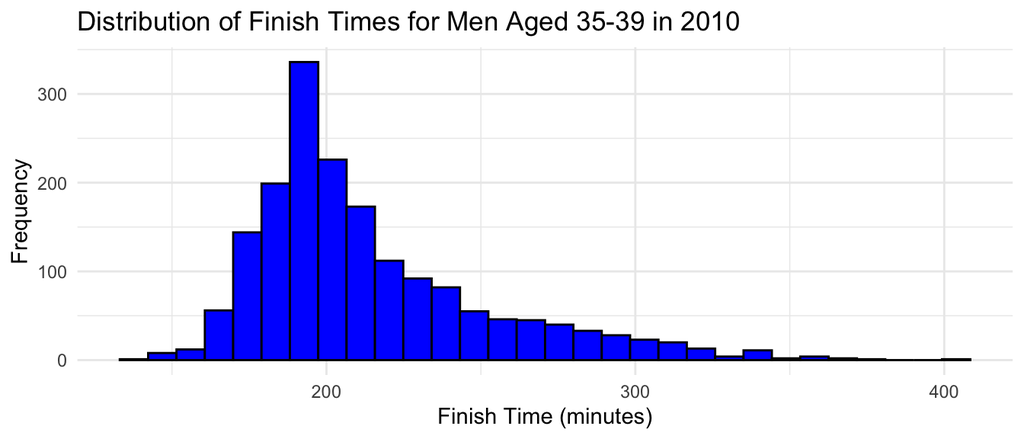

```r
ggplot(men_data, aes(x = Time)) +
  geom_histogram(fill = "blue", color = "black") +
  labs(title = "Distribution of Finish Times for Men Aged 35-39 in 2010",
       x = "Finish Time (minutes)",
       y = "Frequency")
```

-7c. Find a 95% confidence interval for the mean finishing time in the population using methods of the t distribution by direct calculation

```r
n <- summary_stats$size
mean_time <- summary_stats$mean
sd_time <- summary_stats$sd
se_time <- sd_time / sqrt(n)
t_value <- qt(0.975, df = n - 1)

ci_lower <- mean_time - t_value * se_time
ci_upper <- mean_time + t_value * se_time

ci_lower
```

```
## [1] 212.2629
```

```r
ci_upper
```

```
## [1] 215.8531
```

-7d. Repeat the calculations using the `t.test()` function

```r
t_test_result <- t.test(men_data$Time, conf.level = 0.95)
t_test_result
```

```
##
##  One Sample t-test
##
## data:  men_data$Time
## t = 233.88, df = 1768, p-value < 2.2e-16
## alternative hypothesis: true mean is not equal to 0
## 95 percent confidence interval:
##  212.2629 215.8531
## sample estimates:
## mean of x
##   214.058
```

-7e. Interpret this confidence interval in context following the format of examples from lecture.

#### 8

Treat the finishing times in the Boston Marathon of men aged 35–39 in 2010 and 2011 as two different independent samples. Is there evidence that the mean time to finish the race among a population of potential finishers changed during these two years? Conduct a hypothesis test to support your conclusion.

```r
men_2010 <- boston %>%
  filter(Year == 2010, Age_Range == "35-39", Sex == "male")

men_2011 <- boston %>%
  filter(Year == 2011, Age_Range == "35-39", Sex == "male")

t_test_results <- t.test(men_2010$Time, men_2011$Time,
                         alternative = "two.sided",
                         conf.level = 0.95)

t_test_results
```

```
##
##  Welch Two Sample t-test
##
## data:  men_2010$Time and men_2011$Time
## t = 1.2249, df = 3608.6, p-value = 0.2207
## alternative hypothesis: true difference in means is not equal to 0
## 95 percent confidence interval:
##  -0.9477035  4.1031083
## sample estimates:
## mean of x mean of y
##  214.0580  212.4803
```

> Hypotheses

$H_0: \mu_{2010} = \mu_{2011}$

$H_A: \mu_{2010} \neq \mu_{2011}$

Where $\mu_{2010}$ is the population mean finishing time for men aged 35-39 in 2010, and $\mu_{2011}$ is the population mean finishing time for men aged 35-39 in 2011.

> Conclusion

Given the results of the Welch Two Sample t-test, where the p-value is 0.2207, we do not reject the null hypothesis $\mu_{2010} = \mu_{2011}$. This indicates that there is no significant evidence to suggest a difference in the mean finishing times for men aged 35-39 in the Boston Marathon between the years 2010 and 2011. The confidence interval for the difference in means, ranging from -0.9477 to 4.1031 minutes, includes zero, further supporting the conclusion that the differences in average finishing times between these two years are not significant. Thus, we conclude that the finishing times for this age group did not change significantly from 2010 to 2011.